# ESM 244 Lab 2 Part 1

Wrangling continued, PCA

Allison Horst

1/13/2020

## A. Get the data

Data:

- California pollution burden (California Office of Environmental Health Hazard Assessment (OEHHA)’s CalEnviroScreen database, https://oehha.ca.gov/calenviroscreen/maps-data/download-data). See metadata (included as separate file).
- California county demographics (from: CA census 2010)

Read it in:

```r
ca_pb <- read_csv("ca_pollution_burden.csv")
```

```r
ca_dem <- read_csv("ca_census_demographics_2010.csv")
```

## B. Do some cleaning

1. For the pollution burden data:
- Clean up the column headers
- Exclude any column that is a calculated percentile (contains ‘percentile’, ‘perc’, or ‘pctl’)

```r
ca_pb_nopct <- ca_pb %>%
  clean_names() %>%
  select(-contains("pctl")) %>%
  select(-contains("perc")) %>%
  select(-latitude, - longitude)
```

2. For the demographic data:
- Clean up column names

```r
ca_dem_clean <- ca_dem %>%
  clean_names()
```

3. PCA for pollution burden indicator variables

First, starting with ca_pb_nopct:

**Note**: The pollution burden and population characteristic variables are aggregates (averages) of existing variables in the data frame, so we won’t include those. That means we’ll include columns:

- From `ozone:solid_waste`, and
- Frome `asthma:housing_burden`

First, just selecting those:

```r
ca_pb_subset <- ca_pb_nopct %>%
  select(ozone:solid_waste, asthma:housing_burden)
```

We’ll use the `prcomp` function: - ?prcomp

```r
pb_pca <- prcomp(ca_pb_subset, scale = TRUE) # hmmm an error
```

Look at the NA situation:

```r
summary(ca_pb_subset) # Max NAs in a variable: 242 (/8035)
```

```
##      ozone             pm2_5          diesel_pm       drinking_water
##  Min.   :0.02600   Min.   : 1.651   Min.   :  0.021   Min.   :   6.92
##  1st Qu.:0.04000   1st Qu.: 8.698   1st Qu.:  8.812   1st Qu.: 249.35
##  Median :0.04600   Median :10.370   Median : 16.448   Median : 479.23
##  Mean   :0.04743   Mean   :10.378   Mean   : 19.196   Mean   : 472.37
##  3rd Qu.:0.05500   3rd Qu.:12.050   3rd Qu.: 24.646   3rd Qu.: 664.07
##  Max.   :0.06800   Max.   :19.600   Max.   :253.731   Max.   :1245.65
##                    NA's   :19                         NA's   :18
##    pesticides        tox_release          traffic         cleanup_sites
##  Min.   :    0.00   Min.   :     0.0   Min.   :   22.41   Min.   :  0.00
##  1st Qu.:    0.00   1st Qu.:    94.8   1st Qu.:  442.07   1st Qu.:  0.00
##  Median :    0.00   Median :   474.0   Median :  699.89   Median :  2.00
##  Mean   :  313.97   Mean   :  3182.7   Mean   :  943.04   Mean   :  8.37
##  3rd Qu.:    0.37   3rd Qu.:  3474.2   3rd Qu.: 1190.08   3rd Qu.: 10.30
##  Max.   :91316.19   Max.   :842751.3   Max.   :45687.87   Max.   :323.75
##                                        NA's   :56
##  groundwater_threats   haz_waste       imp_water_bodies  solid_waste
##  Min.   :   0.0      Min.   : 0.0000   Min.   : 0.000   Min.   : 0.000
##  1st Qu.:   0.2      1st Qu.: 0.0000   1st Qu.: 0.000   1st Qu.: 0.000
##  Median :   5.6      Median : 0.0500   Median : 1.000   Median : 0.200
##  Mean   :  15.7      Mean   : 0.4534   Mean   : 3.279   Mean   : 2.233
##  3rd Qu.:  17.8      3rd Qu.: 0.2250   3rd Qu.: 6.000   3rd Qu.: 2.250
##  Max.   :1610.2      Max.   :28.6950   Max.   :34.000   Max.   :97.800
##
##      asthma       low_birth_weight cardiovascular_disease   education
##  Min.   :  0.00   Min.   : 0.000   Min.   : 0.000         Min.   : 0.00
##  1st Qu.: 29.86   1st Qu.: 3.950   1st Qu.: 6.080         1st Qu.: 6.30
##  Median : 45.27   Median : 4.920   Median : 7.940         Median :14.00
##  Mean   : 51.98   Mean   : 4.976   Mean   : 8.266         Mean   :19.12
##  3rd Qu.: 65.99   3rd Qu.: 5.930   3rd Qu.:10.040         3rd Qu.:28.70
##  Max.   :278.83   Max.   :14.890   Max.   :21.260         Max.   :80.00
##                   NA's   :222                             NA's   :96
##  linguistic_isolation    poverty       unemployment    housing_burden
##  Min.   : 0.00        Min.   : 0.00   Min.   :  0.00   Min.   : 1.00
##  1st Qu.: 3.00        1st Qu.:19.20   1st Qu.:  6.60   1st Qu.:12.90
##  Median : 7.40        Median :33.50   Median :  9.30   Median :18.00
##  Mean   :10.42        Mean   :36.39   Mean   : 10.21   Mean   :19.33
##  3rd Qu.:14.90        3rd Qu.:51.50   3rd Qu.: 12.90   3rd Qu.:24.40
##  Max.   :72.30        Max.   :96.20   Max.   :100.00   Max.   :67.20
##  NA's   :242          NA's   :79      NA's   :155      NA's   :157
```

A little aside: the `naniar` package for exploring missingness! See: https://naniar.njtierney.com/

Use `naniar::gg_miss_var()` to plot the number of missings by variable:

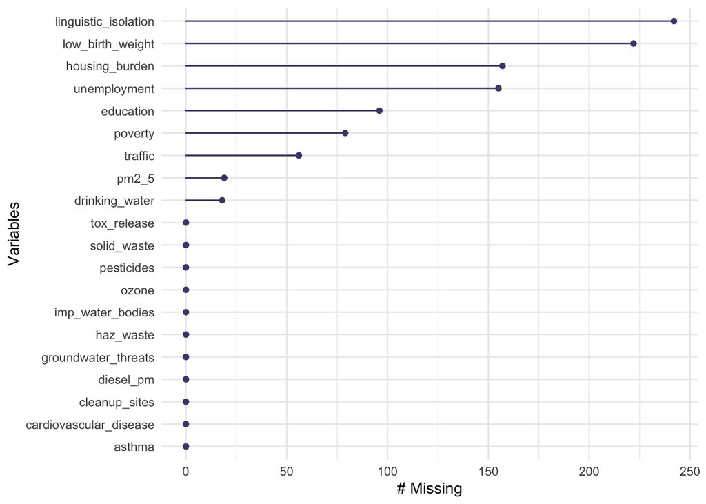

```r
# Plot number of missings by variable
gg_miss_var(ca_pb_subset)
```

We can also explore NAs visually in other ways using the `VIM` package.

The `VIM::matrixplot()` function creates a heatmap, where values are shown on a continuous grayscale, and missings are in red:

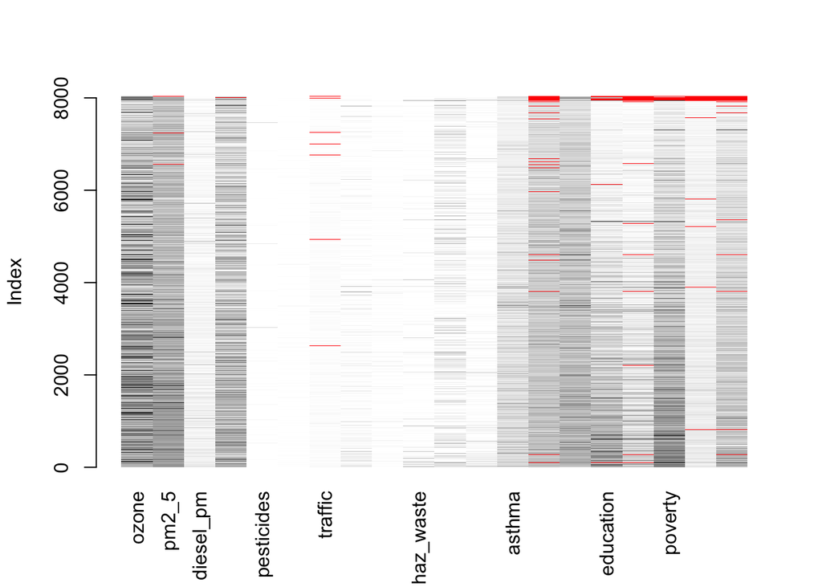

```
##
## Click in a column to sort by the corresponding variable.
## To regain use of the VIM GUI and the R console, click outside the plot region.
```

```r
matrixplot(ca_pb_subset)
```

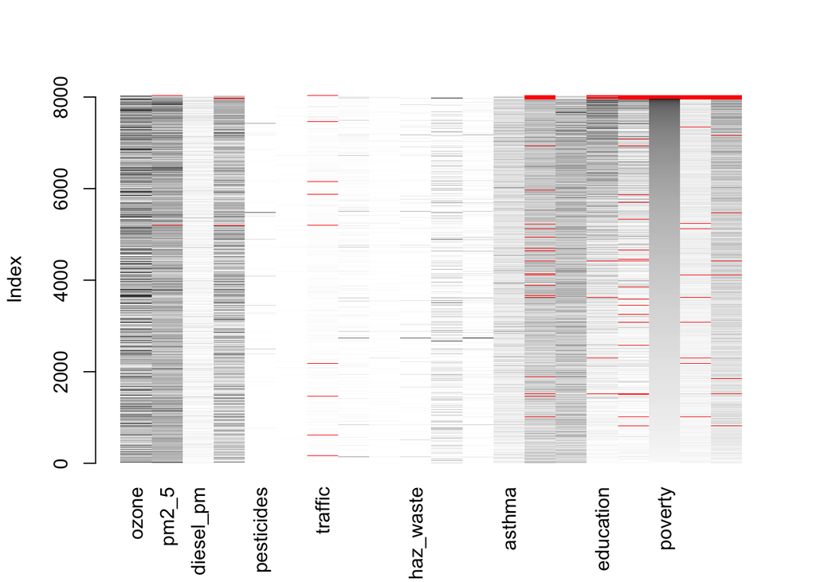

```
##
## Click in a column to sort by the corresponding variable.
## To regain use of the VIM GUI and the R console, click outside the plot region.
```

```r
# We can also sort by a variable of interest. Let's say we want to sort by poverty:
matrixplot(ca_pb_subset, sortby = "poverty")
```

Let’s say our conclusion is that there are missings, but not many (compared to the actual scope of the data). We’ll only keep our complete cases (census tracts without any missings).

Use `tidyr::drop_na()` with no variables specified to keep complete cases across all variables:

```r
ca_pb_nona <- ca_pb_subset %>%
  drop_na()

# Now check for NAs:
summary(ca_pb_nona)
```

```
##      ozone            pm2_5          diesel_pm       drinking_water
##  Min.   :0.0260   Min.   : 1.869   Min.   :  0.021   Min.   :   6.92
##  1st Qu.:0.0400   1st Qu.: 8.698   1st Qu.:  9.267   1st Qu.: 250.35
##  Median :0.0460   Median :10.370   Median : 16.811   Median : 479.23
##  Mean   :0.0474   Mean   :10.436   Mean   : 19.440   Mean   : 473.74
##  3rd Qu.:0.0550   3rd Qu.:12.050   3rd Qu.: 24.760   3rd Qu.: 664.07
##  Max.   :0.0680   Max.   :19.600   Max.   :208.400   Max.   :1245.65
##    pesticides        tox_release          traffic         cleanup_sites
##  Min.   :    0.00   Min.   :     0.0   Min.   :   22.41   Min.   :  0.000
##  1st Qu.:    0.00   1st Qu.:   107.9   1st Qu.:  452.78   1st Qu.:  0.000
##  Median :    0.00   Median :   496.4   Median :  709.76   Median :  2.000
##  Mean   :  308.94   Mean   :  3231.0   Mean   :  956.51   Mean   :  8.184
##  3rd Qu.:    0.32   3rd Qu.:  3614.3   3rd Qu.: 1210.19   3rd Qu.: 10.150
##  Max.   :91316.19   Max.   :842751.3   Max.   :45687.87   Max.   :323.750
##  groundwater_threats   haz_waste       imp_water_bodies  solid_waste
##  Min.   :   0.00     Min.   : 0.0000   Min.   : 0.00    Min.   : 0.000
##  1st Qu.:   0.30     1st Qu.: 0.0000   1st Qu.: 0.00    1st Qu.: 0.000
##  Median :   5.75     Median : 0.0600   Median : 1.00    Median : 0.200
##  Mean   :  15.40     Mean   : 0.4336   Mean   : 3.23    Mean   : 2.178
##  3rd Qu.:  17.75     3rd Qu.: 0.2250   3rd Qu.: 6.00    3rd Qu.: 2.250
##  Max.   :1610.25     Max.   :25.5550   Max.   :34.00    Max.   :97.800
##      asthma       low_birth_weight cardiovascular_disease   education
##  Min.   :  3.63   Min.   : 0.000   Min.   : 1.560         Min.   : 0.00
##  1st Qu.: 30.47   1st Qu.: 3.970   1st Qu.: 6.150         1st Qu.: 6.40
##  Median : 45.95   Median : 4.920   Median : 8.020         Median :14.20
##  Mean   : 52.54   Mean   : 4.981   Mean   : 8.326         Mean   :19.28
##  3rd Qu.: 66.41   3rd Qu.: 5.930   3rd Qu.:10.080         3rd Qu.:28.90
##  Max.   :223.30   Max.   :13.380   Max.   :21.260         Max.   :80.00
##  linguistic_isolation    poverty       unemployment   housing_burden
##  Min.   : 0.00        Min.   : 1.00   Min.   : 0.00   Min.   : 1.00
##  1st Qu.: 3.10        1st Qu.:19.20   1st Qu.: 6.60   1st Qu.:12.90
##  Median : 7.60        Median :33.60   Median : 9.30   Median :18.10
##  Mean   :10.54        Mean   :36.43   Mean   :10.16   Mean   :19.36
##  3rd Qu.:15.00        3rd Qu.:51.70   3rd Qu.:12.80   3rd Qu.:24.60
##  Max.   :72.30        Max.   :94.90   Max.   :41.10   Max.   :60.80
```

```r
# Or use `skimr::skim()`!
skim(ca_pb_nona)
```

Data summary

| Name | ca_pb_nona |
| --- | --- |
| Number of rows | 7557 |
| Number of columns | 20 |
| _______________________ |  |
| Column type frequency: |  |
| numeric | 20 |
| ________________________ |  |
| Group variables | None |

**Variable type: numeric**

| skim_variable | n_missing | complete_rate | mean | sd | p0 | p25 | p50 | p75 | p100 | hist |
| --- | --- | --- | --- | --- | --- | --- | --- | --- | --- | --- |
| ozone | 0 | 1 | 0.05 | 0.01 | 0.03 | 0.04 | 0.05 | 0.06 | 0.07 | ▂▅▇▃▃ |
| pm2_5 | 0 | 1 | 10.44 | 2.56 | 1.87 | 8.70 | 10.37 | 12.05 | 19.60 | ▁▃▇▂▁ |
| diesel_pm | 0 | 1 | 19.44 | 16.50 | 0.02 | 9.27 | 16.81 | 24.76 | 208.40 | ▇▁▁▁▁ |
| drinking_water | 0 | 1 | 473.74 | 249.71 | 6.92 | 250.35 | 479.23 | 664.07 | 1245.65 | ▆▆▇▃▁ |
| pesticides | 0 | 1 | 308.94 | 2687.36 | 0.00 | 0.00 | 0.00 | 0.32 | 91316.19 | ▇▁▁▁▁ |
| tox_release | 0 | 1 | 3230.97 | 12740.97 | 0.00 | 107.91 | 496.35 | 3614.35 | 842751.33 | ▇▁▁▁▁ |
| traffic | 0 | 1 | 956.51 | 917.13 | 22.41 | 452.78 | 709.76 | 1210.19 | 45687.87 | ▇▁▁▁▁ |
| cleanup_sites | 0 | 1 | 8.18 | 16.03 | 0.00 | 0.00 | 2.00 | 10.15 | 323.75 | ▇▁▁▁▁ |
| groundwater_threats | 0 | 1 | 15.40 | 35.21 | 0.00 | 0.30 | 5.75 | 17.75 | 1610.25 | ▇▁▁▁▁ |
| haz_waste | 0 | 1 | 0.43 | 1.38 | 0.00 | 0.00 | 0.06 | 0.22 | 25.55 | ▇▁▁▁▁ |
| imp_water_bodies | 0 | 1 | 3.23 | 4.44 | 0.00 | 0.00 | 1.00 | 6.00 | 34.00 | ▇▂▁▁▁ |
| solid_waste | 0 | 1 | 2.18 | 4.62 | 0.00 | 0.00 | 0.20 | 2.25 | 97.80 | ▇▁▁▁▁ |
| asthma | 0 | 1 | 52.54 | 30.30 | 3.63 | 30.47 | 45.95 | 66.41 | 223.30 | ▇▆▁▁▁ |
| low_birth_weight | 0 | 1 | 4.98 | 1.54 | 0.00 | 3.97 | 4.92 | 5.93 | 13.38 | ▁▇▅▁▁ |
| cardiovascular_disease | 0 | 1 | 8.33 | 2.93 | 1.56 | 6.15 | 8.02 | 10.08 | 21.26 | ▃▇▅▁▁ |
| education | 0 | 1 | 19.28 | 16.02 | 0.00 | 6.40 | 14.20 | 28.90 | 80.00 | ▇▃▂▁▁ |
| linguistic_isolation | 0 | 1 | 10.54 | 9.94 | 0.00 | 3.10 | 7.60 | 15.00 | 72.30 | ▇▂▁▁▁ |
| poverty | 0 | 1 | 36.43 | 20.30 | 1.00 | 19.20 | 33.60 | 51.70 | 94.90 | ▇▇▆▅▁ |
| unemployment | 0 | 1 | 10.16 | 4.90 | 0.00 | 6.60 | 9.30 | 12.80 | 41.10 | ▇▇▂▁▁ |
| housing_burden | 0 | 1 | 19.36 | 8.68 | 1.00 | 12.90 | 18.10 | 24.60 | 60.80 | ▅▇▃▁▁ |

Cool. No NAs, checked out missingness, NOW let’s try PCA again:

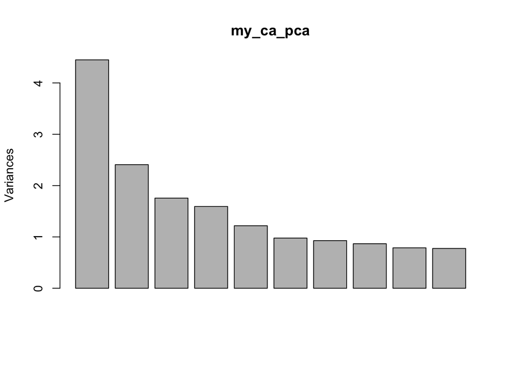

```r
my_ca_pca <- prcomp(ca_pb_nona, scale = TRUE)

# A nightmare! But what are we looking at?
plot(my_ca_pca)
```

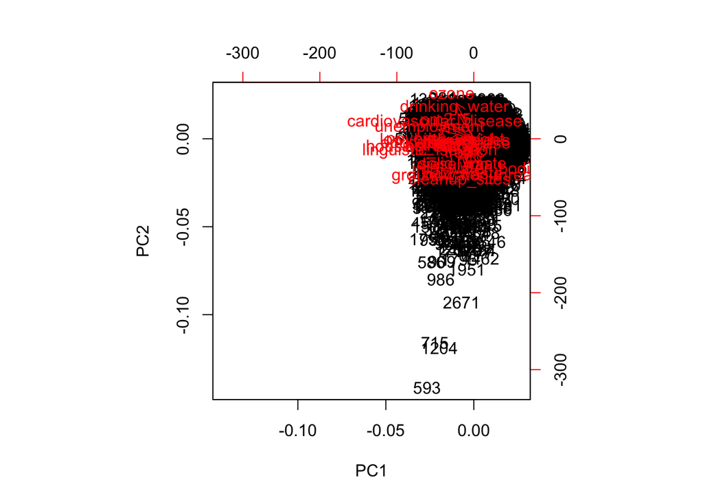

```r
biplot(my_ca_pca)
```

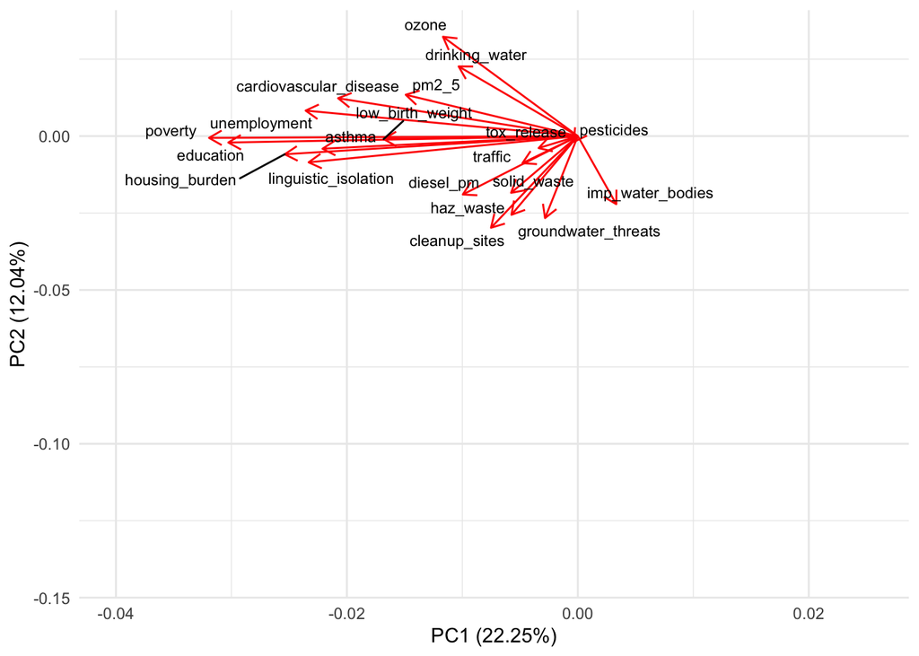

```r
# Hmmm let's try something else (this requires ggfortify):
my_biplot <- autoplot(my_ca_pca,
                      colour = NA,
                      loadings.label = TRUE,
                      loadings.label.size = 3,
                      loadings.label.colour = "black",
                      loadings.label.repel = TRUE) +
  theme_minimal()


my_biplot
```

4. Join data by census tract (inner join)

```r
ca_df <- ca_dem_clean %>%
  inner_join(ca_pb_nopct, by = c("census_tract_number" = "census_tract"))
```

Check it out, then get complete cases:

```r
ca_df_nona <- ca_df %>%
  drop_na()
```

5. Make a new subset for PCA, that includes % white and elderly, and some interesting pollution burden & health indicators:

Like (you can choose a different set):

- white_percent
- elderly_65_percent
- pm2_5
- pesticides
- traffic
- asthma
- cardiovascular_disease
- poverty

Make our subset:

```r
my_sub <- ca_df_nona %>%
  select(white_percent, elderly_65_percent, pm2_5, pesticides, traffic, asthma, cardiovascular_disease, poverty)
```

Then run PCA:

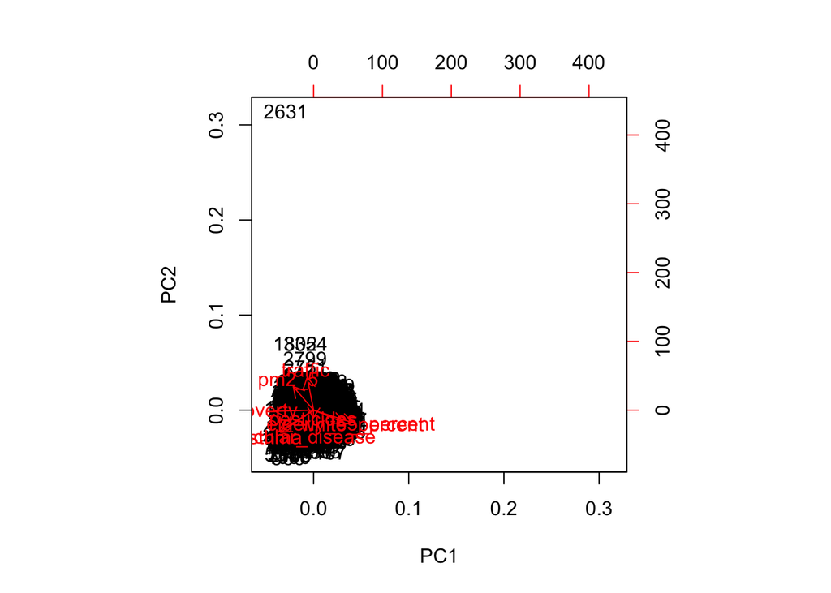

```r
my_dem_pca <- prcomp(my_sub, scale = TRUE)
biplot(my_dem_pca) # Noooo. We need better
```

Check it out a bit:

```r
# Proportion of variance (& cumulative variance) explained by each PC
summary(my_dem_pca)
```

```
## Importance of components:
##                           PC1    PC2    PC3    PC4     PC5     PC6     PC7
## Standard deviation     1.7005 1.1328 1.0093 0.9137 0.88262 0.74998 0.59132
## Proportion of Variance 0.3614 0.1604 0.1273 0.1043 0.09738 0.07031 0.04371
## Cumulative Proportion  0.3614 0.5219 0.6492 0.7536 0.85093 0.92124 0.96494
##                            PC8
## Standard deviation     0.52958
## Proportion of Variance 0.03506
## Cumulative Proportion  1.00000
```

```r
# Rotations (linear combinations for each PC):
my_dem_pca
```

```
## Standard deviations (1, .., p=8):
## [1] 1.7004635 1.1328316 1.0093031 0.9136826 0.8826233 0.7499840 0.5913152
## [8] 0.5295792
##
## Rotation (n x k) = (8 x 8):
##                                 PC1         PC2         PC3         PC4
## white_percent           0.477718534 -0.22883645  0.12981439 -0.06648613
## elderly_65_percent      0.365575897 -0.22272840  0.17638340 -0.31406708
## pm2_5                  -0.248918199  0.43250416  0.10953210  0.41026586
## pesticides             -0.005641416 -0.14402871 -0.93956564 -0.11990925
## traffic                -0.079244666  0.60338880  0.02490694 -0.77366682
## asthma                 -0.427873008 -0.39740200  0.14478535 -0.29124929
## cardiovascular_disease -0.404775430 -0.40964129  0.17705040 -0.17471436
## poverty                -0.472174749 -0.02023448 -0.06577423  0.01826350
##                                PC5         PC6         PC7         PC8
## white_percent           0.13824837 -0.30282161 -0.54892826  0.53479989
## elderly_65_percent      0.55799887  0.55663350  0.09031914 -0.24007488
## pm2_5                   0.72721539 -0.12386950 -0.01106601  0.16234587
## pesticides              0.27245991 -0.08343848 -0.01150758  0.02707906
## traffic                 0.01419948 -0.13117491 -0.10763067  0.03832356
## asthma                  0.10746388 -0.02362194  0.46121229  0.57304811
## cardiovascular_disease  0.21283574 -0.43523654 -0.32645620 -0.51495181
## poverty                -0.09694771  0.60741821 -0.59949191  0.18502833
```

Make a sweet biplot:

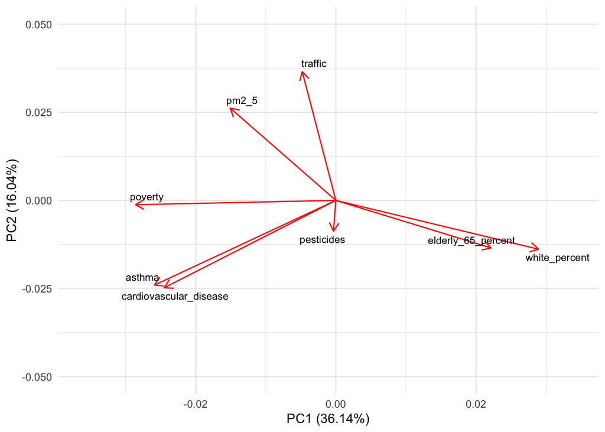

```r
my_dem_biplot <- autoplot(my_dem_pca,
                      colour = NA,
                      loadings.label = TRUE,
                      loadings.label.size = 3,
                      loadings.label.colour = "black",
                      loadings.label.repel = TRUE) +
  theme_minimal() +
  scale_y_continuous(limits = c(-0.05, 0.05))

my_dem_biplot
```

What are a few main things we can take out of this? What are the main correlations you notice? Are they in line with what you would expect, or is anything surprising?